# Aula 13 - Diamantes

### Scatterplot Review

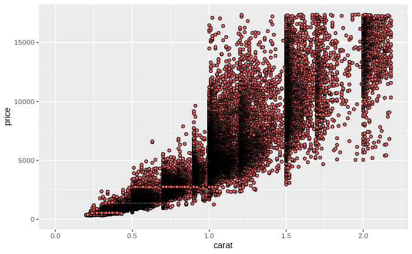

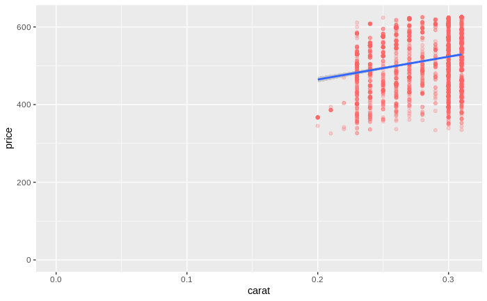

### Price and Carat Relationship

Response: Existe uma relação não linear por camadas entre cada carat e uma concentração de seu preço. De certa forma, após a concentração, pode-se dizer que há uma progressão de crescimento de acordo com carat para o preço.

### Frances Gerety

Notes:

### The Rise of Diamonds

Notes:

### ggpairs Function

Notes:

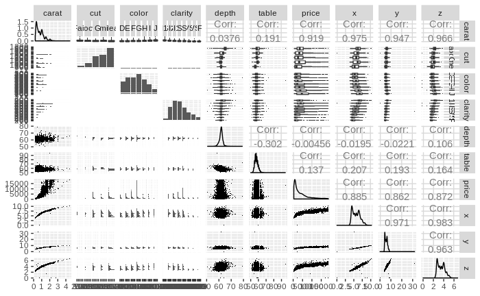

What are some things you notice in the ggpairs output? Response: As variáveis de maior impacto são o tamanho, consistidos em volume e o peso em carat.

### The Demand of Diamonds

Notes:

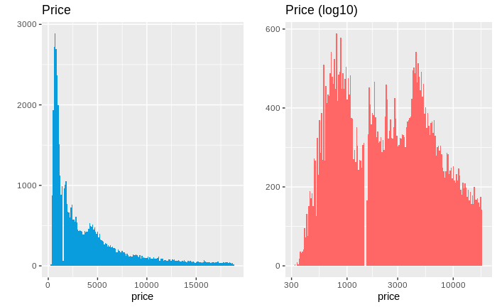

### Connecting Demand and Price Distributions

Notes:

### Scatterplot Transformation

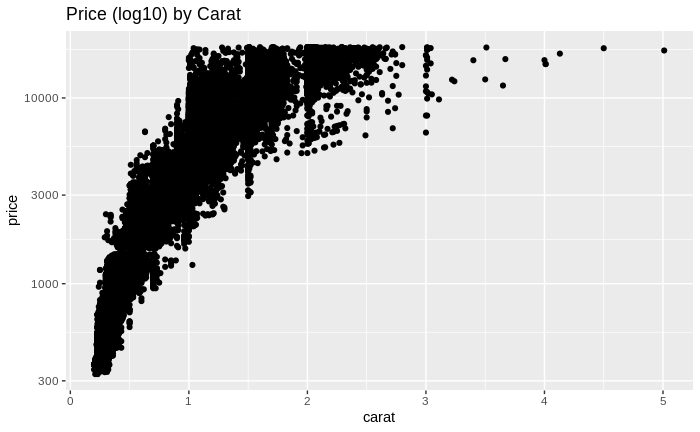

### Create a new function to transform the carat variable

#### Use the cuberoot_trans function

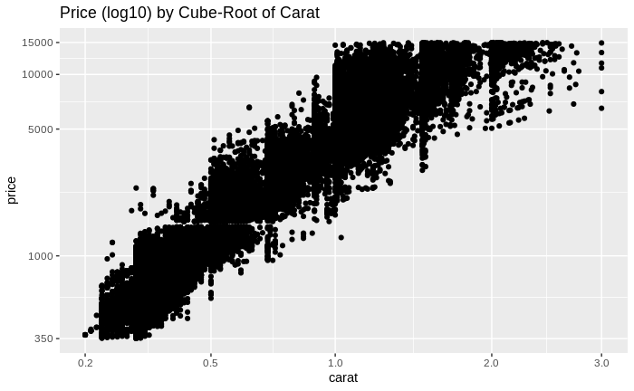

### Overplotting Revisited

```r
head(sort(table(diamonds$carat), decreasing = T))
```

```
 0.3 0.31 1.01  0.7 0.32    1
2604 2249 2242 1981 1840 1558
```

```r
head(sort(table(diamonds$price), decreasing = T))
```

```
605 802 625 828 776 698
132 127 126 125 124 121
```

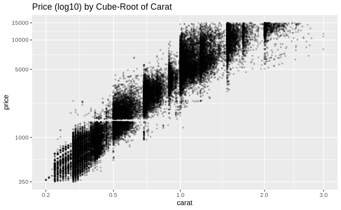

### Other Qualitative Factors

Notes:

### Price vs. Carat and Clarity

Alter the code below.

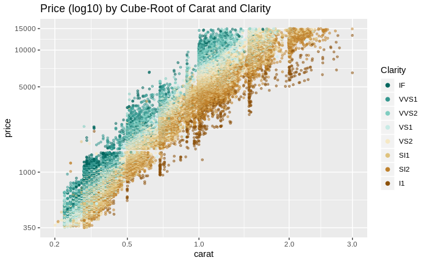

### Clarity and Price

Response:

### Price vs. Carat and Cut

Alter the code below.

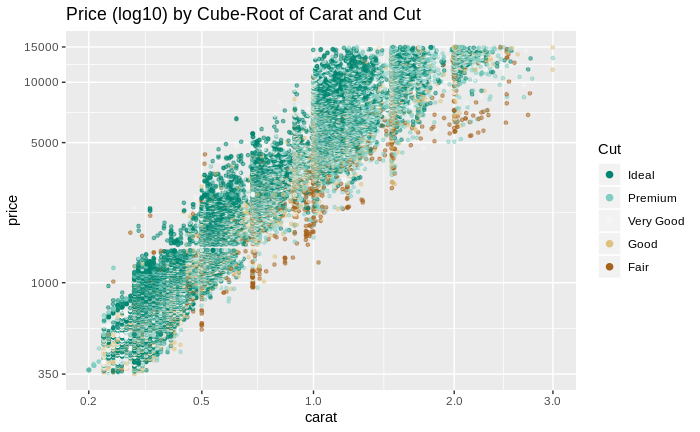

### Price vs. Carat and Color

Alter the code below.

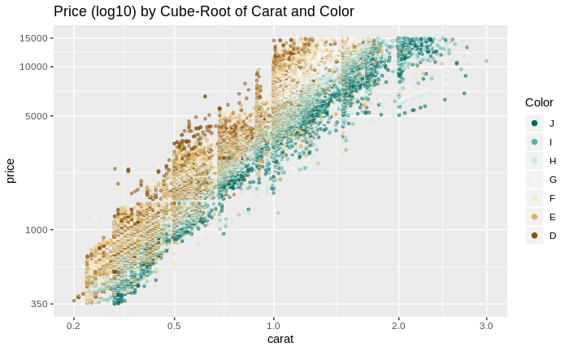

### Color and Price

Response: Sim pois há a mesma gradação de cor como visto anteriormente. ***

### Linear Models in R

Notes:

Response:

### Building the Linear Model

Notes:

```r
mtable(m1, m2, m3, m4, m5)
```

```
Calls:
m1: lm(formula = I(log(price)) ~ I(carat^(1/3)), data = diamonds)
m2: lm(formula = I(log(price)) ~ I(carat^(1/3)) + carat, data = diamonds)
m3: lm(formula = I(log(price)) ~ I(carat^(1/3)) + carat + cut, data = diamonds)
m4: lm(formula = I(log(price)) ~ I(carat^(1/3)) + carat + cut + color,
    data = diamonds)
m5: lm(formula = I(log(price)) ~ I(carat^(1/3)) + carat + cut + color +
    clarity, data = diamonds)

========================================================================================
                       m1            m2            m3            m4            m5
----------------------------------------------------------------------------------------
  (Intercept)         2.821***      1.039***      0.874***      0.932***      0.415***
                     (0.006)       (0.019)       (0.019)       (0.017)       (0.010)
  I(carat^(1/3))      5.558***      8.568***      8.703***      8.438***      9.144***
                     (0.007)       (0.032)       (0.031)       (0.028)       (0.016)
  carat                            -1.137***     -1.163***     -0.992***     -1.093***
                                   (0.012)       (0.011)       (0.010)       (0.006)
  cut: .L                                         0.224***      0.224***      0.120***
                                                 (0.004)       (0.004)       (0.002)
  cut: .Q                                        -0.062***     -0.062***     -0.031***
                                                 (0.004)       (0.003)       (0.002)
  cut: .C                                         0.051***      0.052***      0.014***
                                                 (0.003)       (0.003)       (0.002)
  cut: ^4                                         0.018***      0.018***     -0.002
                                                 (0.003)       (0.002)       (0.001)
  color: .L                                                    -0.373***     -0.441***
                                                               (0.003)       (0.002)
  color: .Q                                                    -0.129***     -0.093***
                                                               (0.003)       (0.002)
  color: .C                                                     0.001        -0.013***
                                                               (0.003)       (0.002)
  color: ^4                                                     0.029***      0.012***
                                                               (0.003)       (0.002)
  color: ^5                                                    -0.016***     -0.003*
                                                               (0.003)       (0.001)
  color: ^6                                                    -0.023***      0.001
                                                               (0.002)       (0.001)
  clarity: .L                                                                 0.907***
                                                                             (0.003)
  clarity: .Q                                                                -0.240***
                                                                             (0.003)
  clarity: .C                                                                 0.131***
                                                                             (0.003)
  clarity: ^4                                                                -0.063***
                                                                             (0.002)
  clarity: ^5                                                                 0.026***
                                                                             (0.002)
  clarity: ^6                                                                -0.002
                                                                             (0.002)
  clarity: ^7                                                                 0.032***
                                                                             (0.001)
----------------------------------------------------------------------------------------
  R-squared           0.924         0.935         0.939         0.951         0.984
  N               53940         53940         53940         53940         53940
========================================================================================
  Significance: *** = p < 0.001; ** = p < 0.01; * = p < 0.05
```

Notice how adding cut to our model does not help explain much of the variance in the price of diamonds. This fits with out exploration earlier.

### Model Problems

Video Notes:

Research: (Take some time to come up with 2-4 problems for the model) (You should 10-20 min on this)

Response:

### A Bigger, Better Data Set

Notes:

```r
install.package('bitops')
install.packages('RCurl')
library('bitops')
library('RCurl')

diamondsurl = getBinaryURL("https://raw.github.com/solomonm/diamonds-data/master/BigDiamonds.Rda")
load("BigDiamonds.Rda")
```

The code used to obtain the data is available here: https://github.com/solomonm/diamonds-data

## Building a Model Using the Big Diamonds Data Set

Notes:

```r
diamondsbig$logprice = log(diamondsbig$price)
diamondsbig$logprice = log(diamondsbig$price)
m1 <- lm(logprice ~ I(carat^(1/3)),
         data = diamondsbig[diamondsbig$price < 10000 &
                              diamondsbig$cert == "GIA",])
m2 <- update(m1, ~ . + carat)
m3 <- update(m2, ~ . + cut)
m2 <- update(m1, ~ . + carat)
m3 <- update(m2, ~ . + cut)
m4 <- update(m3, ~ . + color)
m4 <- update(m3, ~ . + color)
m5 <- update(m4, ~ . + clarity)
m4 <- update(m3, ~ . + color)
m5 <- update(m4, ~ . + clarity)
mtable(m1, m2, m3, m4, m5)
```

```
Calls:
m1: lm(formula = logprice ~ I(carat^(1/3)), data = diamondsbig[diamondsbig$price <
    10000 & diamondsbig$cert == "GIA", ])
m2: lm(formula = logprice ~ I(carat^(1/3)) + carat, data = diamondsbig[diamondsbig$price <
    10000 & diamondsbig$cert == "GIA", ])
m3: lm(formula = logprice ~ I(carat^(1/3)) + carat + cut, data = diamondsbig[diamondsbig$price <
    10000 & diamondsbig$cert == "GIA", ])
m4: lm(formula = logprice ~ I(carat^(1/3)) + carat + cut + color,
    data = diamondsbig[diamondsbig$price < 10000 & diamondsbig$cert ==
        "GIA", ])
m5: lm(formula = logprice ~ I(carat^(1/3)) + carat + cut + color +
    clarity, data = diamondsbig[diamondsbig$price < 10000 & diamondsbig$cert ==
    "GIA", ])

=============================================================================================
                       m1             m2             m3             m4             m5
---------------------------------------------------------------------------------------------
  (Intercept)          2.671***       1.333***       0.949***       0.529***      -0.464***
                      (0.003)        (0.012)        (0.012)        (0.010)        (0.009)
  I(carat^(1/3))       5.839***       8.243***       8.633***       8.110***       8.320***
                      (0.004)        (0.022)        (0.021)        (0.017)        (0.012)
  carat                              -1.061***      -1.223***      -0.782***      -0.763***
                                     (0.009)        (0.009)        (0.007)        (0.005)
  cut: V.Good                                        0.120***       0.090***       0.071***
                                                    (0.002)        (0.001)        (0.001)
  cut: Ideal                                         0.211***       0.181***       0.131***
                                                    (0.002)        (0.001)        (0.001)
  color: K/L                                                        0.123***       0.117***
                                                                   (0.004)        (0.003)
  color: J/L                                                        0.312***       0.318***
                                                                   (0.003)        (0.002)
  color: I/L                                                        0.451***       0.469***
                                                                   (0.003)        (0.002)
  color: H/L                                                        0.569***       0.602***
                                                                   (0.003)        (0.002)
  color: G/L                                                        0.633***       0.665***
                                                                   (0.003)        (0.002)
  color: F/L                                                        0.687***       0.723***
                                                                   (0.003)        (0.002)
  color: E/L                                                        0.729***       0.756***
```

[output cut: 9 more lines]

```
  clarity: VS2                                                                     0.836***
                                                                                  (0.006)
  clarity: VS1                                                                     0.891***
                                                                                  (0.006)
  clarity: VVS2                                                                    0.935***
                                                                                  (0.006)
  clarity: VVS1                                                                    0.995***
                                                                                  (0.006)
  clarity: IF                                                                      1.052***
                                                                                  (0.006)
---------------------------------------------------------------------------------------------
  R-squared            0.888          0.892          0.899          0.937          0.969
  N               338946         338946         338946         338946         338946
=============================================================================================
  Significance: *** = p < 0.001; ** = p < 0.01; * = p < 0.05
```

## Predictions

Example Diamond from BlueNile: Round 1.00 Very Good I VS1 $5,601

Evaluate how well the model predicts the BlueNile diamond’s price. Think about the fitted point estimate as well as the 95% CI.

## Final Thoughts

Notes:

Click **KnitHTML** to see all of your hard work and to have an html page of this lesson, your answers, and your notes!